# R Notebook

## Assignment 3 - Diagnosing schizophrenia from voice

In the previous part of the assignment you generated a bunch of “features”, that is, of quantitative descriptors of voice in schizophrenia, focusing on pitch. In the course of this assignment we will use them to try to automatically diagnose schizophrenia from voice only, that is, relying on the set of features you produced last time, we will try to produce an automated classifier.

### Question 1: Can you diagnose schizophrenia from pitch range only? If so, how well?

Build a logistic regression to see whether you can diagnose schizophrenia from pitch range only.

Calculate the different performance measures (accuracy, sensitivity, specificity, PPV, NPV, ROC curve) on a logistic regression using the full dataset. Don’t forget the random effects!

Then cross-validate the logistic regression and re-calculate performance on the testing folds. N.B. The cross-validation functions you already have should be tweaked: you need to calculate these new performance measures.

N.B. the predict() function generates log odds (the full scale between minus and plus infinity). Log odds > 0 indicates a choice of 1, below a choice of 0. N.B. you need to decide whether calculate performance on each single test fold or save all the prediction for test folds in one datase, so to calculate overall performance. N.B. Now you have two levels of structure: subject and study. Should this impact your cross-validation?

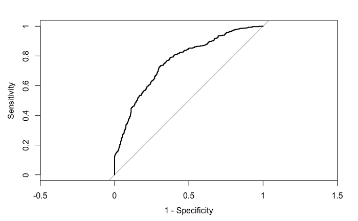

### Question 2

Which single predictor is the best predictor of diagnosis?

```r
summary(ENTRresults)
```

```
    Accuracy       Sensitivity      Specificity          PPV              NPV
 Min.   :0.5553   Min.   :0.4144   Min.   :0.5458   Min.   :0.5240   Min.   :0.5249
 1st Qu.:0.5565   1st Qu.:0.4561   1st Qu.:0.5926   1st Qu.:0.5810   1st Qu.:0.5593
 Median :0.5841   Median :0.5687   Median :0.6650   Median :0.6012   Median :0.5872
 Mean   :0.5878   Mean   :0.5235   Mean   :0.6580   Mean   :0.6114   Mean   :0.5795
 3rd Qu.:0.6061   3rd Qu.:0.5755   3rd Qu.:0.6696   3rd Qu.:0.6377   3rd Qu.:0.5901
 Max.   :0.6368   Max.   :0.6027   Max.   :0.8168   Max.   :0.7132   Max.   :0.6360
      AUC
 Min.   :0.5313
 1st Qu.:0.5607
 Median :0.6110
 Mean   :0.6066
 3rd Qu.:0.6494
 Max.   :0.6808
```

### Question 3 - Which combination of acoustic predictors is best for diagnosing schizophrenia?

Now it’s time to go wild! Use all (voice-related) variables and interactions you can think of. Compare models and select the best performing model you can find.

Remember: - Out-of-sample error crucial to build the best model! - After choosing the model, send Celine and Riccardo the code of your model

```r
mean(combination4$AUC) # mean AUC(.637)*
```

```
[1] 0.6371967
```